# Image Processing Using Python Imaging Library (PIL)

### Introduction

The main goal of this tutorial is to get you familiar with some features of image manipulation and processing through the use of PIL library for Python. Before you can test and work with image processing through python, you will need to have installed an additional library called PIL or Python Imaging Library and a fork called *Pillow* which has different tools to manipulate the image once the library is installed as you will see in the following sections.

> The basic steps to install the library are described [here](https://pillow.readthedocs.io/en/latest/installation.html#windows-installation) based on the type of user (MAC or WINDOWS); it also explains the which version of pillow is supported by Python 3.X. Although, if you are using anaconda, just make sure that your pillow version is up to date, since PIL/pillow is within the packages installed in Anaconda.

For the purposes of this tutorial we will be using five images. This is a sample of one of the images in its original format and closer to its original size:

> <img src="https://github.com/wvelebanks/Tutorial-03-18/blob/master/Tutorial-03-18/Tutorial/Images/racoon.jpg" width =700 height=700>

The following topics will be covered in this tutorial:

- Importing libraries
- Opening and Changing File Extension
- Working with Image Features
- Manipulating Image Pixels
- Summary

# Importing Libraries

Below is the code for importing all the libraries used throught the tutorial to accomodate content within the notebook.

```python
# All the imports needed for the entire notebook are listed on this section
import nbconvert
from PIL import Image, ImageFilter, ImageOps     #------>  main Library for this tutorial
from matplotlib.pyplot import imshow
import matplotlib.pyplot as plt
from pylab import *                              #------>  allow us to manipulate the arrays formed
import numpy as np
import os                                        #------>  To work with a group of pictures in a folder
```

# Opening and Changing Image File Extensions

Once we have added all the necessary imports, we will work first on importing the original image into the nothebook.

This section below displays the image as you saw it above with its original size. if the image is within the same directory of the notebook, we only need to add the name.extension of the image when calling it; else we will need the full path from the folder located in this [repository](https://github.com/wvelebanks/Tutorial-03-18/tree/master/Tutorial/Images)

you can download the entire folder and name it Images on your computer

In our case the image is saved within the the folder of this notebook.

```
The format for "myimage" is  JPEG
```

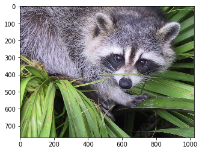

```python
#we open the original file in JPEG extension
myimage = Image.open("Images/Racoon.jpg")

# The original image  is displayed in windows photo viewer and
# it comes up just as the one displayed at the beginning of the notebook.
myimage.show()

# The file format of the source file.
print("The format for \"myimage\" is ", myimage.format)

# we modify the file by ssving it with different file extension
myimage.save("Images/racoonPNG.png")

#Displaying the image as a graph within the notebook using numpy
%matplotlib inline
myimage = Image.open("Images/racoon.jpg", 'r')

# converts the image to a numpy array
imshow(np.asarray(myimage))
```

The .show() outputs the image with the default photo viewer on show on the screen:

> <img src="Tutorial-03-18/Tutorial/Images/imshow.JPG" width =500 height=500>

Displaying the image as the graph above will be extremely useful to manipulate the pixels in the following subsections of this tutorial.

# Working with Image Features

This segment works with:

- Size
- Color
- Resolution and neatness
- Rotation and Cropping an image
- Pasting and image into another image

We will modify the size and the output image into multiple sizes and change the dimensions of the image.

Resizing images can result very useful; particularly, when storing significant amounts of images into a database, or when extracting them from a server. making them into a smaller and uniform size in order to fit them into a dataset.

```python
# specify the size for the image
myimage2 = Image.open("Images/Parrot.jpg")

# Image original size, in pixels. The size is given as a 2-tuple (width, height).
print("Original Image Size: ", myimage2.size)

# we set the size of the thumbnail we want to create out of the original image
size250 = (250,250)

# converts the original image into a thumbnail of the size specified above
myimage2.thumbnail(size250)
myimage2.save("Images/image4.jpg")

# The pixel format used by the image. Typical values are “1”, “L”, “RGB”, or “CMYK.”
print("Image Mode: ", myimage2.mode)

# Color palette table, if any.
print("The palette for this image: ", myimage2.palette)

# To change the color to black and white
myimage2.convert(mode ='L').save("Images/image5.jpg")

# To make a blurry image
# The default value is set to 2 which does not make much of a difference
# but if incremented you will see a notorious difference in the clarity of the image
myimage2.filter(ImageFilter.GaussianBlur(15)).save("Images/BlurryParrot.jpg")

#rotate the image
myimage2.rotate(45).save("Images/ParrotRotated45.jpg")

#cropping and image
box = (95, 95, 180, 180)                         #---> First we create the box that will select the area we want to crop
cropped_image = myimage2.crop(box)               #---> Crops the section we want
cropped_image.save("Images/cropped_Parrot.jpg")  #---> Saves the cropped image
```

```
Original Image Size:  (750, 484)
Image Mode:  RGB
The palette for this image:  None
```

The above code, we work with the variable **_myimage2_**, which opens and generates in the images in the Images folder:

> <img src="Tutorial-03-18/Tutorial/Images/Parrot.jpg" width =500 height=500>

#### Thumbnail

Thumbnails are commonly used to protect images particularly in the web that have copyrights, and can be display only to a certain size.

<img src="Tutorial-03-18/Tutorial/Images/image4.jpg" width =250 height=250>

#### Black and White

In image processing is common to use black and white images most referred as "gray scale" images.

<img src="Tutorial-03-18/Tutorial/Images/image5.jpg" width =300 height=300>

Applications where machines are the main subject such as in computer vision or an application that deals with object detection would barely require information at the edges of an image, and therefore is perfectly fine to work with gray scale images.

#### Blurry Image

A classic and very useful example of image convolution is Gaussian blurring of images.

<img src="Tutorial-03-18/Tutorial/Images/BlurryParrot.jpg" width =300 height=300>

In essence, the (grayscale) image I is convolved with a Gaussian kernel to create a blurred version: Iσ = I * Gσ

#### Image Rotated 45 degrees

<img src="Tutorial-03-18/Tutorial/Images/ParrotRotated45.jpg" width =290 height=290>

Rotation of images is particularly useful in the biomedical field particularly when images are enhanced as 3-D, and result extremely helpful to study particular deseases.

#### Cropped Image

By cropping an image the outer parts of an image are removed to improve framing, accentuate subject matter or change aspect ratio.

<img src="Tutorial-03-18/Tutorial/Images/cropped_Parrot.jpg" width =150 height=150>

#### Pasting an Image into Another Image

This is usually used in advertisement where a logo is within the image. Also,on images that used watermarks on them, and in general where images are merged together.

From our Images folder, we load two images "cockatoo" being the main image and "moon-logo" as the logo

> Images/Cockatoo.jpg and Images/moon-logo.jpg

Below, myimage3 is the background image or the bigger image in the final output, logo is the image that will serve as the signature image contained in the background image.

we then create a copy of the background image in order to generate the dimmensions for the position of the logo in the resulting output. Then we paste the logo in the position previously calculated with the background image and finally we save the result of the two images merged.

```python
# Opens the image that will serve as the main/background image
myimage3 = Image.open("Images/Cockatoo.jpg")

#Opens the image that will serve as the logo/smaller image
logo = Image.open("Images/moon-logo.jpg")

#Created the image to be copied
image_copy = myimage3.copy()

# we set the position of the image within the bigger image
position = ((image_copy.width - logo.width), (image_copy.height - logo.height))

# and finally we paste the smaller image  (Foreground) into the bigger image (background)
image_copy.paste(logo, position)

# Saves the new merged image
image_copy.save("Images/pasted_image.jpg")
```

in the above code section, we are working with myimage3 which opens and creates the following:

##### Bakcground Image: <img src="Images/Cockatoo.jpg" width =400 height=400>

##### Foreground Image: <img src="Images/moon-logo.jpg" width =100 height=100>

The Resulting image is the merged of both images in one:

<img src="Images/pasted_image.jpg" width =400 height=400>

#### Changing Image Tonalities

- **Embossing** on which we hihglight and replace the boundaries with low contrast, and set a gray background on the image. this teachnique calculates the first derivative of the image and combines it with a uniform grayscale.
- **Edge Detection** works by detecting discontinuities in brightness; Edge detection is used for image segmentation and data extraction in areas such as image processing, computer vision, and machine vision.
- **Colorization** Colorization is commonly used in image processing particularly to lower image resolution to colorize a black-and-white photo, space missions relied upon this technique to keep data volumes low.
- **Solarization** is a technique which can be applied to any negative in the printing process.

```python
# Opens the Cockatoo image file
myimage9 = Image.open("Images/Cockatoo.jpg")

#creates a image with the "Emboss" filter in it
emboss_filter = myimage9.filter(ImageFilter.EMBOSS)

#Shows the image in the photo viewer
emboss_filter.show()

#saves the image in the folder specified
emboss_filter.save("Images/emboss.jpg")
```

Image result after applying the **emboss** filter:

<img src="Images/emboss.jpg" width =300 height=300>

```python
# applies the "find_edges" filter
find_edges = myimage9.filter(ImageFilter.FIND_EDGES)

# display the output image in the photo viewer
find_edges.show()

# saves the output image in the folder Images
find_edges.save("Images/find_edges.jpg")
```

Image result from the photo viewer after applying the *find_edges* filter:

<img src="Images/find_edges.jpg" width =300 height=300>

```python
# Opens a gray scale image of the Cockatoo
myimage10 = Image.open("Images/Cockatoo.jpg").convert("L")

# Changes the color of the image into a bluish color by using the colorize filter
myimage11 = ImageOps.colorize( myimage10, black="midnightblue", white="white")

#Save the resulting image with the new color
myimage11.save("Images/ColorizedImage.jpg")

# display the output image in the photo viewer
myimage11.show()
```

Image result from the photo viewer after applying the **_Colorized_** filter:

<img src="Images/ColorizedImage.jpg" width =300 height=300>

```python
# Opens a gray scale image of the Cockatoo
myimage10 = Image.open("Images/Cockatoo.jpg")

# the first we apply the default value in the threshold parameter to solarize the image
result = ImageOps.solarize(myimage10, threshold=128)

# saves image with 128 threshold
result.save("Images/solarizeImage1.jpg")

# then  we changed the values for the threshold parameter to 50
result = ImageOps.solarize(myimage10, threshold=50)

# saves image with 50 threshold
result.save("Images/solarizeImage2.jpg")

# finally  we changed the values for the threshold parameter to 0 which is the same as using ImageOps.invert filter
result = ImageOps.solarize(myimage10, threshold=0)

# saves image with 0 threshold
result.save("Images/solarizeImage3.jpg")

# Show the last resulted image
result.show()
```

Image results from the photo viewer after applying the **_Solarization_** filter:

#### Solarize 1:

> <img src="Images/solarizeImage1.jpg" width =300 height=300>

#### Solarize 2:

> <img src="Images/solarizeImage2.jpg" width =300 height=300>

#### Solarize 3:

> <img src="Images/solarizeImage3.jpg" width =300 height=300>

# Manipulating Image Pixels

In this last section we will work with more detailed ways to manipulate an image through its pixels. We will combine some of functions previously showcased to manipulate the image.

Another library useful for this purpose is **_Mathplotlib_** and **_pylab_** because they both allow you to manipulate the numerical data contained in the pixels through the use of arrays, and displaying those values in a form of graph as you will see below with the examples one with a histogram equalization of an image, the change of colors by manipulating the array, and finally drawing lines inside an image with pixel dimensions.

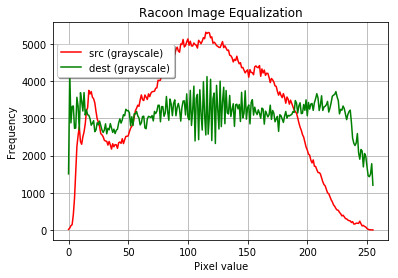

```python
# Image Equalization
# the first line opens the original image
myimage13 = Image.open("Images/racoon.jpg")

# saves the image in black and white (gray scale)
myimage14 = myimage13.convert("L")  # grayscale

# saves the grayscale image to be equalized
myimage14.save("Images/equalizeImage.jpg")

# Equalize the image histogram.
myimage15 = ImageOps.equalize(myimage13)

#saves the first equalization/ (adds more contrast to the image)
myimage15.save("Images/equalizedhist.jpg")

#does the grayscale conversio again of the already equalized image
myimage16 = myimage15.convert("L")

#saves the second equalization of the image
myimage16.save("Images/equalizeRacoon.jpg")

# created and visualize the histogram derived from the different equalizations
# performed in the image
bins = list(range(256))
plt.plot(bins, myimage14.histogram(), 'r')
plt.plot(bins, myimage16.histogram(), 'g')
plt.xlabel('Pixel value')
plt.ylabel('Frequency')
plt.title("Racoon Image Equalization")
plt.legend(
    ('src (grayscale)', 'dest (grayscale)'),
     shadow=True, loc=(0.01, 0.75))
plt.grid(True)
plt.savefig("Images/equalize_hist_01.jpg")
```

The firat output change the original image into a gray scale one:

<img src="Images/equalizeImage.jpg" width =300 height=300>

**Phase 1:** after the first equalization in color

<img src="Images/equalizedhist.jpg" width =300 height=300>

**Phase 2:** last equalization, which converts it into a black and white again

<img src="Images/equalizeRacoon.jpg" width =300 height=300>

<img src="Images/equalize_hist_01.jpg" width =300 height=300>

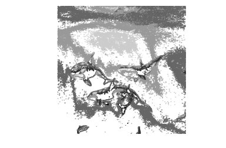

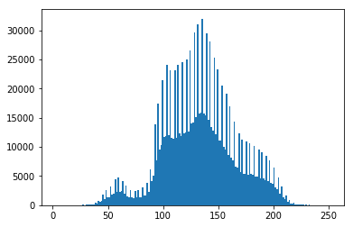

```python
# read image to array
myimage6 = array(Image.open("Images/Orcas.jpg").convert("L"))

# create a new figure
figure()

# the image gets displayed without colors (gray scale)
gray()

# show contours with origin upper left corner
contour(myimage6, origin='image')
axis('equal')
axis('off')

# it creates the figure  for the graph resulting from the rray of the image
figure()

# not adding the .show() function in this section was intentional
# in order to display the values of the array on myimage6 in addition to the histogram formed
# from those values contained in the image
hist(myimage6.flatten(),180)
```

[figure not shown]

```python
#open the image file
myimage4 = Image.open("Images/Orcas.jpg")

# we make another cropped box from myimage4
box = (100,100,400,400)

#saves the selected region
region = myimage4.crop(box)

# we then rotate the image and tranpose it within the region
region = region.transpose(Image.ROTATE_180)

# the paste creates the new image
myimage4.paste(region,box)

# We resize the image with a new feature from the Pillow Library
out = myimage4.resize((128,128))

# and rotate the image once again
out = myimage4.rotate(45)

# read image to array
myimage5 = array(Image.open("Images/Orcas.jpg"))

# plot the image
imshow(myimage5)

# some points
x = [100,100,450,450]
y = [450,700,450,700]

# plot the points with red star-markers
plot(x,y,'r*')

# line plot connecting the first two points
plot(x[:2],y[:2])

# add title and show the plot
title("Plotting: Beautiful Animals.- The Orcas")

# Display the title in the graph
show()
```

# Summary

Image processing is one of the core technologies that enables us to build 3-D maps in real time; another example of its importance comes with the famous selfdriving cars from google, which in this case is the technology that allows them to "see" through the cameras and process those images so they can follow their maps. Another important use comes in the intelligence community, such as FBI, CIA, and Defense on which cases is used on investigation, design and strategy implemetation (plane visualization of war games) respectively. Although this tutorial present **basic** manipulation of images, as explained above the actual use of image processing in complex settings is extremely useful. Besides, knowing how to manipulate images in large scale results beneficial in terms of saving space and is more efficient when referring to performance of retrieving large amounts of images from databases or servers. There are several other features that can be explored to which some of them are listed in the references used for this tutorial.

#### References:

1. [Python Guide for Beginners](http://www.pythonforbeginners.com/gui/how-to-use-pillow)
2. [Using PIL "video"](https://www.youtube.com/watch?v=6Qs3wObeWwc)
3. [Markdown CheatSheet](https://github.com/adam-p/markdown-here/wiki/Markdown-Here-Cheatsheet#blockquotes)
4. [Image Processing in Python with Pillow Tutorial](https://auth0.com/blog/image-processing-in-python-with-pillow/)
5. [ImageOps Documentation Module](https://hhsprings.bitbucket.io/docs/programming/examples/python/PIL/ImageOps.html)
6. [First Steps with PIL](http://www.geeks3d.com/20100930/tutorial-first-steps-with-pil-python-imaging-library/#p04)
7. [PIL Examples with ImageOps](https://www.programcreek.com/python/example/85590/PIL.ImageOps.fit)